# Regression analysis_Homework Assignment 1

## b. For each sample, compute an estimate of $E(y|x = 5)$. Construct a histogram of the estimates you obtained. Discuss the shape of the histogram.

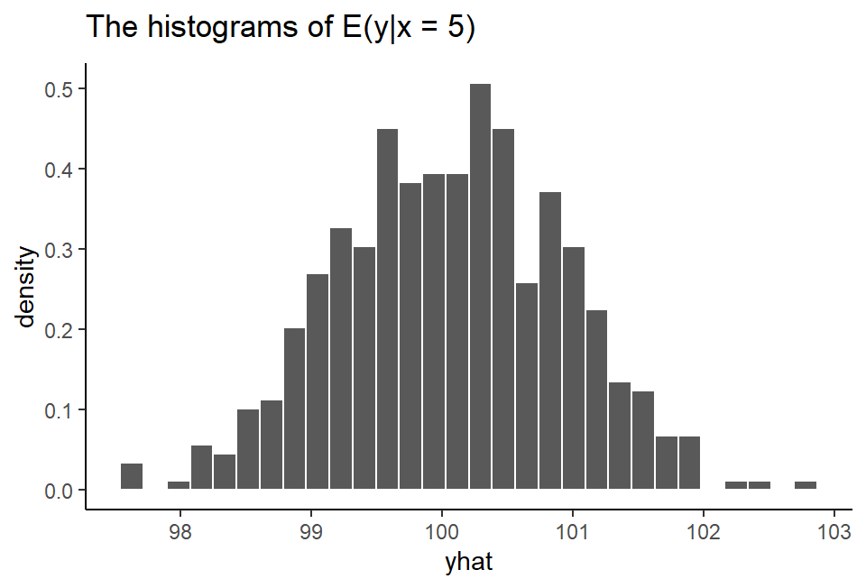

```r
predictsAt5 <- lapply(fitlms, function(.fitlm){
  data.frame(yhat = predict(.fitlm, data.frame(x = 5)))
}) %>%
  bind_rows(.id = "replicate")

ggplot(predictsAt5, aes(x = yhat)) +
  geom_histogram(aes(y = ..density..), color = "white") +
  labs(title = expression(paste("The histograms of E(y|x = 5)"))) +
  theme_classic()
```

The histogram of the conditional expectation estimator $\hat{E(}y|x=5) \equiv \hat{\mu}_{y|x=5}$ is also like bell shape, and it is centered around 100.

## c. For each sample, compute a 95% CI on the slope. How many of these intervals contain the true value $\beta_1 = 10$? Is this what you would expect?

```r
coef_cis <- lapply(fitlms, function(.fitlm){
  as.data.frame(confint(.fitlm, "x", level = 0.95))
}) %>%
  bind_rows(.id = "replicate")

coef_cis %>%
  mutate(contain10 = (`2.5 %` <= 10) & (10 <= `97.5 %`)) %>%
  summarise(confidence = mean(contain10))
```

```
  confidence
1       0.94
```

It finds that $94\%$ of our 500 CI’s, which were constructed from samples respectively, for $\beta_1$ cover 10. This result is close to our expectation at $95\%$.

## d. For each estimate of $E(y|x = 5)$ in part b, compute the 95% CI. How many of these intervals contain the true value of $E(y|x = 5) = 100$? Is this what you would expect?

```r
predictsAt5_cis <- lapply(fitlms, function(.fitlm){
  data.frame(predict(.fitlm, data.frame(x = 5), interval = "confidence"))
}) %>%
  bind_rows(.id = "replicate")

predictsAt5_cis %>%
  mutate(contain100 = (lwr <= 100) & (100 <= upr)) %>%
  summarise(confidence = mean(contain100))
```

```
  confidence
1      0.974
```

It finds that $97.4\%$ in our 500 CI’s for $\hat{E(}y|x=5)$ cover 100. This result is close to our expectation at $95\%$.

# 2. (#2.25) Consider the simple linear regression model $y = \beta_0 + \beta_1x + \varepsilon$, with $E(\varepsilon) = 0$, $Var(\varepsilon) = \sigma^2$, and $\varepsilon$ uncorrelated.

## a. Show that $Cov(\hat{\beta}_0, \hat{\beta}_1) = −x \sigma^2/S_{xx}$

$$\begin{align}
Cov(\hat{\beta}_0, \hat{\beta}_1) &= Cov(\bar{y} - \hat{\beta}_1 \bar{x}, \hat{\beta}_1) \\
&= Cov(\bar{y}, \hat{\beta}_1) - Cov(\hat{\beta}_1 \bar{x}, \hat{\beta}_1)\\
&= 0 - \bar{x} Var(\hat{\beta}_1) & \text{(by part b)} \\
&= -\bar{x} \sigma^2/S_{xx}
\end{align}$$

## b. Show that $Cov(\bar{y}, \hat{\beta}_1) = 0$

$$\begin{align}
Cov(\bar{y}, \hat{\beta}_1) &= Cov(\sum_{i=1}^n \frac{y_i}{n}, \sum_{j=1}^{n} \frac{(x_j-\bar{x})y_j}{S_{xx}}) \\
&= \frac{1}{n S_{xx}} \sum_{i, j} (x_j-\bar{x}) Cov(y_i, y_j)
\end{align}$$

Since $y_i's$ are mutually independent, $Cov(y_i, y_j) = 0$ if $i \neq j$ and $Cov(y_i, y_i) = Var(y_i) = Var(\varepsilon_i) =\sigma^2$. Therefore, we have

$$\begin{align}
Cov(\bar{y}, \hat{\beta}_1) &= \frac{\sigma^2}{n S_{xx}} \sum_{j=1}^n (x_j-\bar{x}) \\
&= 0
\end{align}$$

# 3. (#2.27) Suppose that we have fit the straight-line regression model $\hat{y} = \hat{\beta}_0 + \hat{\beta}_1 x_1$ but the response is affected by a second variable $x_2$ such that the true regression function is $E(y) = \beta_0 + \beta_1 x_1 + \beta_2 x_2$.

## a. Is the least-squares estimator of the slope in the original simple linear regression model unbiased?

$$\begin{align}
E(\hat{\beta}_1) &= E(\sum_{i=1}^n \frac{(x_{1i} - \bar{x}_1)y_i}{S_{xx}}) \\
&= \sum_{i=1}^n \frac{(x_{1i} - \bar{x}_1)}{S_{xx}}E(y_i) \\
&= \sum_{i=1}^n \frac{(x_{1i} - \bar{x}_1)}{S_{xx}} (\beta_0 + \beta_1 x_{1i} + \beta_2 x_{2i}) \\
&= \beta_1 + \beta_2 \frac{\sum_{i=1}^n (x_{1i} - \bar{x}_1) x_{2i}}{S_{xx}}
\end{align}$$

where $\sum_{i=1}^n (x_{1i}-\bar{x}_1) = 0$ and $\sum_{i=1}^n (x_{1i}-\bar{x}_1) x_{1i} = \sum_{i=1}^n (x_{1i}-\bar{x}_1) (x_{1i}-\bar{x}_1) = S_{xx}$. In this situation, the original estimator $\hat{\beta}_1$ is a biased estimator for $\beta_1$.

## b. Show the bias in $\hat{\beta}_1$

$$\begin{align}
Bias_{\beta_1}(\hat{\beta}_1) &= E(\hat{\beta}_1) - \beta_1 \\
&= (\beta_1 + \beta_2 \frac{\sum_{i=1}^n (x_{1i} - \bar{x}_1) x_{2i}}{S_{xx}}) - \beta_1 \\
&= \beta_2 \frac{\sum_{i=1}^n (x_{1i} - \bar{x}_1) x_{2i}}{S_{xx}}
\end{align}$$

# 4. (#2.32) Consider the simple linear regression model $y = \beta_0 + \beta_1 x + \varepsilon$ where the intercept $\beta_0$ is known.

## a. Find the least-squares estimator of $\beta_1$ for this model. Does this answer seem reasonable?

The least-squares criterion is
$$LS(\beta_1) = \sum_{i=1}^n (y_i - \beta_0 - \beta_1 x_i)^2$$
The least-square estimators of $\beta_1$, say $\hat{\beta}_1$, must satisfy

$$\begin{align}
0 &= \frac{d}{d \beta_1} LS(\beta_1) \bigg\rvert_{\hat{\beta}_1} \\
&= -2 \sum_{i=1}^n (y_i - \beta_0 - \hat{\beta}_1 x_i) x_i \\
\end{align}$$

one has

$$\hat{\beta}_1 = \frac{\sum_{i=1}^n (y_i - \beta_0) x_i}{\sum_{i=1}^n x_i^2}$$

It seems reasonable because $\hat{\beta}_1$ is depended on $x_i$ and pure $y_i^* = y_i - \beta_0$ effect, which minus the intercept effect. And this regression line must go through the point $(0, \beta_0)$.

## b. What is the variance of the slope $\left( \hat{\beta}_1 \right)$ for the least-squares estimator found in part a?

$$\begin{align}
Var(\hat{\beta}_1) &= Var \left( \frac{\sum_{i=1}^n (y_i - \beta_0) x_i}{\sum_{i=1}^n x_i^2} \right) \\
&= \frac{1}{(\sum_{i=1}^n x_i^2)^2} \sum_{i=1}^n x_i^2 Var(y_i) \\
&= \frac{\sigma^2}{\sum_{i=1}^n x_i^2}
\end{align}$$

## c. Find a $100(1 − \alpha)$ percent Cl for $\beta_1$. Is this interval narrower than the estimator for the case where both slope and intercept are unknown?

We can get that $E(SS_{RES}) = E(\sum_{i=1}^n (y_i - \hat{y}_i)^2) = (n-1)\sigma^2$, so let $MS_{RES} = \frac{SS_{RES}}{n-1}$ be an unbiased estimator of $\sigma^2$. If we assume $\varepsilon_i's$ are independently and normally distributed with mean $0$ and variance $\sigma^2$, and it can be shown that $\frac{(n-1)MS_{RES}}{\sigma^2} \sim \chi_{n-1}^2$.

Furthermore, $\hat{\beta}_1$ is a linear combination of $\{y_i\}$, so $\hat{\beta}_1 \sim N(E(\hat{\beta}_1) = \beta_1, Var(\hat{\beta}_1) = \frac{\sigma^2}{\sum_{i=1}^n x_i^2})$.

Therefore, the test statistic
$$\begin{align}
T &= \frac{\hat{\beta}_1 - \beta_1}{\sqrt{MS_{RES} / \sum_{i=1}^n x_i^2}} \\
&= \frac{\frac{\hat{\beta}_1 - \beta_1}{\sqrt{\sigma^2 / \sum_{i=1}^n x_i^2}}}{\sqrt{\frac{(n-1)MS_{RES} / \sigma^2}{n-1}}} \\
&\sim \frac{Z}{\sqrt{\frac{\chi_{n-1}^2}{n-1}}} \sim t_{n-1}
\end{align}$$
follows a $t_{n-1}$ distribution. One has
$$\begin{align}
1 - \alpha &= \Pr(t_{1-\alpha/2,n-1} < T = \frac{\hat{\beta}_1 - \beta_1}{\sqrt{MS_{RES} / \sum_{i=1}^n x_i^2}} < t_{\alpha/2,n-1}) \\
&= \Pr(\hat{\beta}_1 - t_{\alpha/2,n-1}\sqrt{\frac{MS_{RES}}{\sum_{i=1}^n x_i^2}} < \beta_1 < \hat{\beta}_1 - t_{1-\alpha/2,n-1}\sqrt{\frac{MS_{RES}}{\sum_{i=1}^n x_i^2}}) \\
&= \Pr(\hat{\beta}_1 - t_{\alpha/2,n-1}\sqrt{\frac{MS_{RES}}{\sum_{i=1}^n x_i^2}} < \beta_1 < \hat{\beta}_1 + t_{\alpha/2,n-1}\sqrt{\frac{MS_{RES}}{\sum_{i=1}^n x_i^2}})
\end{align}$$
So the $100(1 - \alpha)\%$ CI for $\beta_1$ is $\hat{\beta}_1 \pm t_{\alpha/2,n-1}\sqrt{\frac{MS_{RES}}{\sum_{i=1}^n x_i^2}}$.

On the other hand, the $100(1 - \alpha)\%$ CI of $\beta_1$ for the case where both unknown slope and intercept is $\hat{\beta}_1 \pm t_{\alpha/2,n-2}\sqrt{\frac{MS_{RES}^*}{\sum_{i=1}^n (x_i-\bar{x})^2}}$, where $MS_{RES}^* = \frac{SS_{RES}}{(n-2)} > \frac{SS_{RES}}{(n-1)} = MS_{RES}$. One can check that $t_{\alpha/2,n-2}\sqrt{\frac{1}{n-2}} > t_{\alpha/2,n-1}\sqrt{\frac{1}{n-1}} \quad \forall \alpha, n \geq 2$.

Finally, the $100(1 - \alpha)\%$ CI for $\beta_1$ when $\beta_0$ is known is narrower than one when $\beta_0$ & $\beta_1$ are unknown.

# 5. (#2.33) Consider the least-squares residuals $e_i = y_i − \hat{y}_i, i = 1, 2, \dots, n$, from the simple linear regression model. Find the variance of the residuals $Var(e_i)$ . Is the variance of the residuals a constant? Discuss.

$$\begin{align}
Var(e_i) &= Var(y_i − \hat{y}_i) \\
&= Var(y_i) + Var(\hat{y}_i) - 2 Cov(y_i, \hat{y}_i) \\
&= \sigma^2 + Var(\hat{\beta}_0 + \hat{\beta}_1 x_i) - 2 Cov(y_i, \hat{\beta}_0 + \hat{\beta}_1 x_i) \\
&= \sigma^2 + Var(\bar{y} + \hat{\beta}_1 (x_i - \bar{x})) - 2 Cov(y_i, \bar{y} + \hat{\beta}_1 (x_i - \bar{x})))
\end{align}$$

Since from Exercise 2.25 part (b), we know $Cov(\bar{y}, \hat{\beta}_1) = 0$. Therefore, the variance of the residual $e_i$ is

$$\begin{align}
Var(e_i) &= \sigma^2 + Var(\bar{y}) + (x_i - \bar{x})^2 Var(\hat{\beta}_1) - 2[Cov(y_i, \bar{y}) + (x_i - \bar{x}) Cov(y_i, \frac{\sum_{i=1}^n (x_i - \bar{x}) y_i}{S_{xx}})] \\
&= \sigma^2 + \sigma^2 (\frac{1}{n} + \frac{(x_i - \bar{x})^2}{S_{xx}}) - 2[\frac{1}{n} Var(y_i) + \frac{(x_i - \bar{x})^2}{S_{xx}}Var(y_i)] \qquad (\text{since } y_i's \text{ are independent}) \\
&= \sigma^2 + \sigma^2 (\frac{1}{n} + \frac{(x_i - \bar{x})^2}{S_{xx}}) - 2\sigma^2 (\frac{1}{n} + \frac{(x_i - \bar{x})^2}{S_{xx}}) \\
&= \sigma^2 (1 - \frac{1}{n} - \frac{(x_i - \bar{x})^2}{S_{xx}})
\end{align}$$

We can find that the variance of the residual $e_i$ which depends on the $x_i$ is not a constant. The $Var(e_i)$ is decreasing as the distance $\left | x_i - \bar{x} \right |$ increases.